# Predicted coverage analysis: accuracy and outliars

```r
source('~/HexamerBias/artificial_coverage/compare_peaks.r')
```

```
Update all/some/none? [a/s/n]:
```

```r
n
```

## Loading the data

I have calculated experimental and artificial coverage for a set of randomly sampled regions with high coverage. Load bigWig files.

```r
pred.bw <- import(pred.bw.file, format = 'BigWig')
pred.bw <- import(pred.bw.file, format = 'BigWig')
```

Merge experimental and predicted coverage files, at base resolution level.

```r
common.bw <- make.predVSexp.range(pred.bw = pred.bw, exp.bw = exp.bw.base)
common.bw <- make.predVSexp.range(pred.bw = pred.bw, exp.bw = exp.bw.base)
```

Normalization

```r
norm.common.bw <- normalize.coverage(common.bw)
norm.common.bw <- add.id(norm.common.bw)
```

Splitting into GRanges lists for mapping functions

```r
l.common.bw <- split(common.bw, common.bw$id)
l.norm.common.bw <- split(norm.common.bw, norm.common.bw$id)
lon.norm.commo <- l.norm.common.bw[sapply(l.norm.common.bw, length)==4999] ## Remove ranges of length 1 (something to fix in add.id)
```

Kernel smoothing of normalized coverage

```r
l.norm.smooth.common <- lapply(lon.norm.commo, smooth.coverage)
```

```
Error in `[[<-`(`*tmp*`, name, value = c(8.61497814746181e-08, 8.61497814746181e-08,  :
  100 elements in value to replace 1 elements
```

## Plotting genomic regions

```
The following non-numeric data column has been dropped: id
```

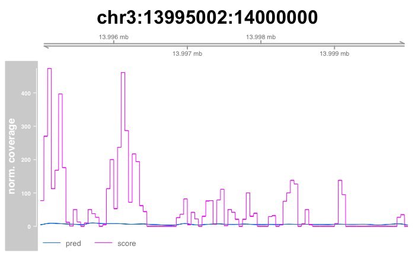

```r
plot.expVSpred.coverage.track(test.bw)
```

## Correlations and similarity

Spearman correlation measures if the two profiles have the same modality (so if the ranking is maintained, regarless of amplitude of peaks), while the Pearson correlation measures linear correlation, so it considers amplitude of peaks.

```r
correlation <- correlation %>%
  filter(pear.p<0.05 & spear.p<0.05) %>%
  select(-pear.p, -spear.p)# Filter out unsignificant correlations
```

```
Error in filter_impl(.data, quo) : Result must have length 4509, not 4543
```

For both metrics the correlation is significantly higher than random.

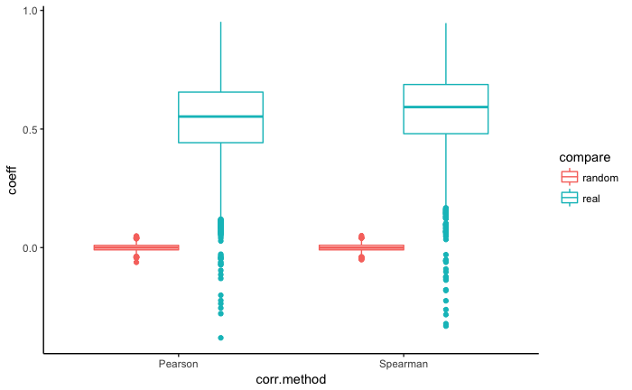

Try again shuffling labels of regions and not values inside the regions:

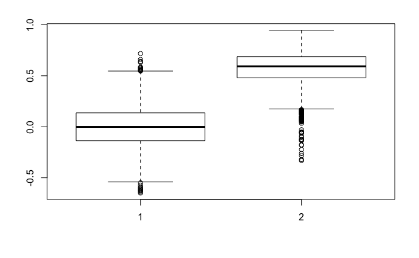

Good concordance between linear correlation (PCC) and ranked correlation (Spearman).

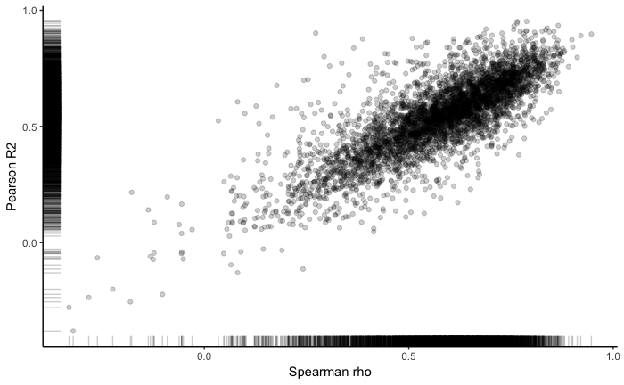

## Ranking adjustment

In all the sampled regions we can see there is a baseline and a general underestimation of peaks in the prediction, even though the modalities are usually conserved between predicted and experimental coverage. This means that the ranking are generally the same (–> High spearman Rho).

Plotting ranked values for predicted (red) and experimental (black)

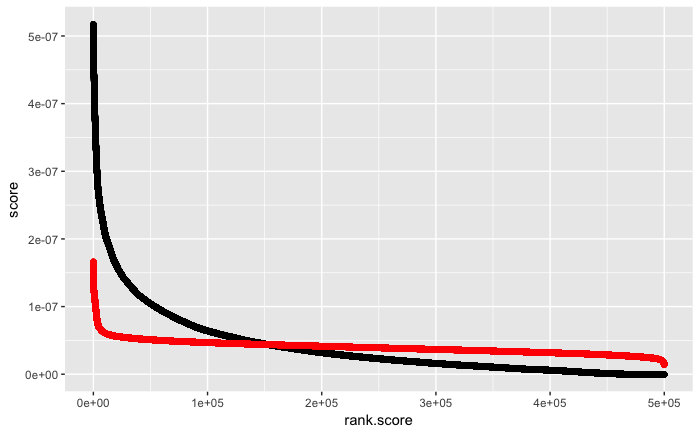

N.B. The ranking is not exactly the same for the same basepairs in the same regions!! But it follows the same trend as seen above, so we can assume that the ranking is the same.

Showing the ranked data we can say that the coverage score of intersection of the two distributions is the baseline value for the predicted coverage (underneath the experimental coverage is practically 0).

Under the assumption that the ranking is conserved between predicted and experimental coverage score, we can fit an exponential model to the rank of the experimental coverage.
$$cov_{e} = \beta \cdot exp(rank(cov_{e}))\\$$
From the experimental coverage I compute the parameters and then adjust the predicted value by fitting it’s rank to the model:
$$adj.cov_p = \beta \cdot exp(rank(cov_p))$$

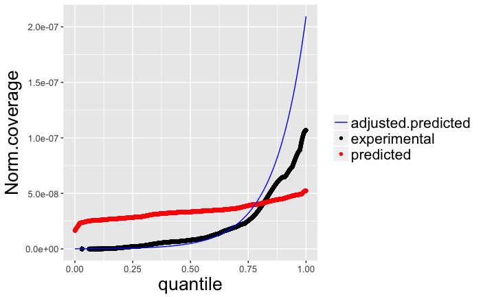

So the profile after the adjustment looks like this

```
The following non-numeric data column has been dropped: id
```

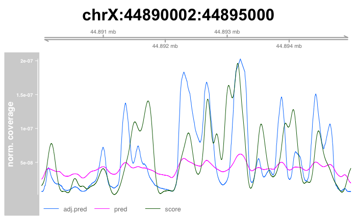

```r
plot.expVSpred.coverage.track(adj.smp[[1]])
```

Does this improve the PCC? The Spearman doesn’t change because the ranking is conserved.

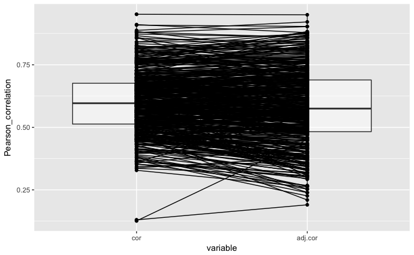

Well not much…

What’s the point then? Not sure…

## Outliars: no correlation

Find and visualize regions with low spearman correlation

```
The following non-numeric data column has been dropped: id
```

[output not shown]

[output cut: 211 more lines]

[output not shown]

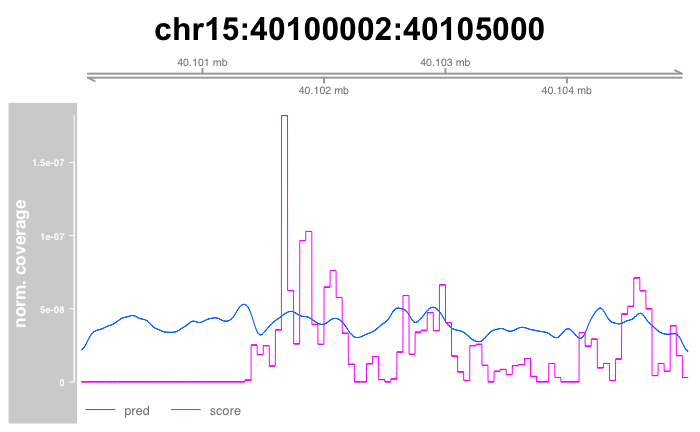

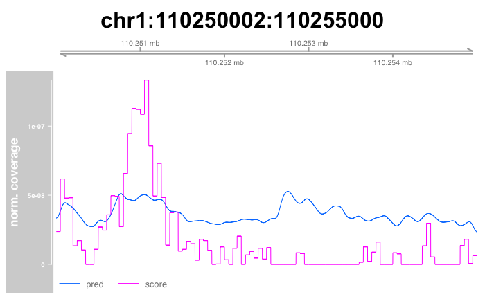

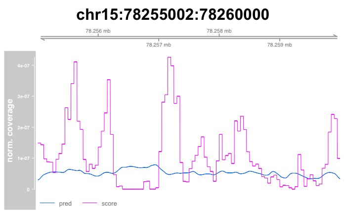

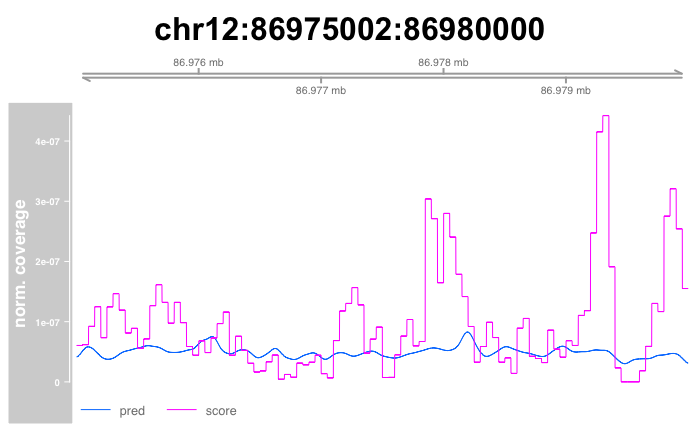

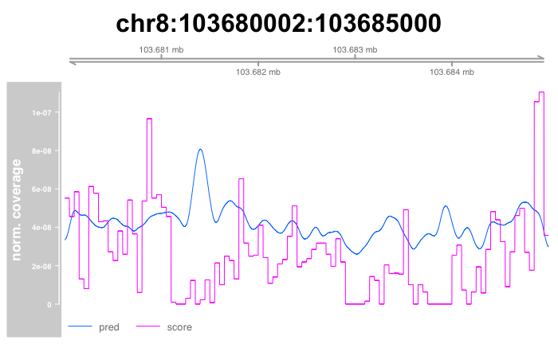

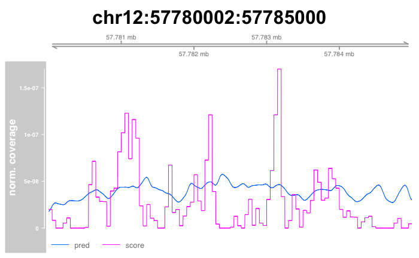

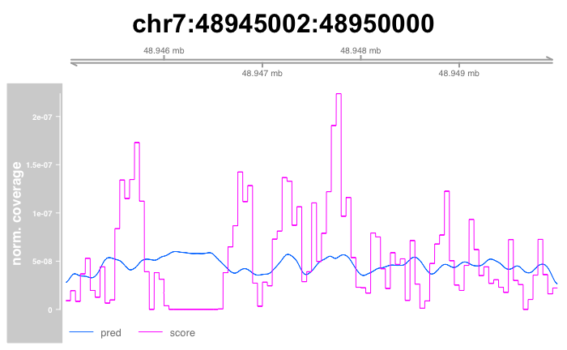

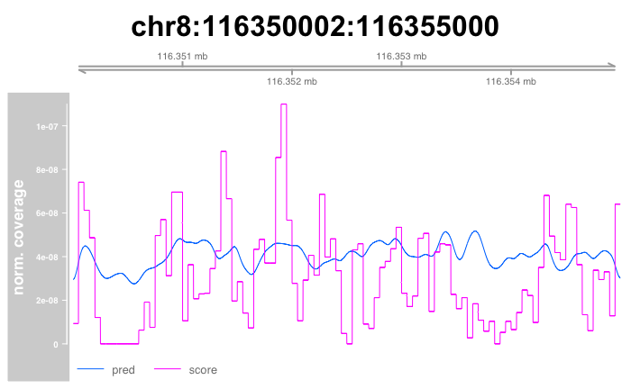

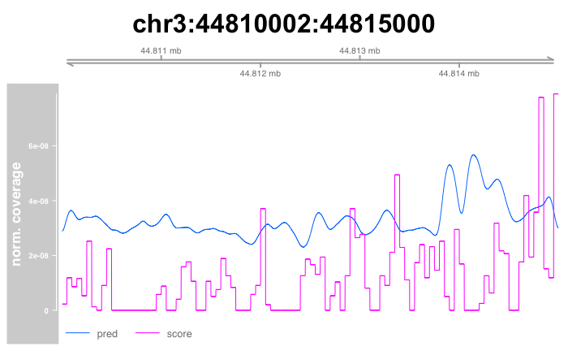

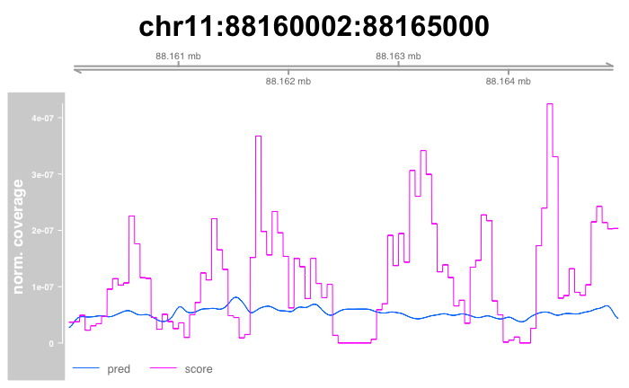

```r
lapply(sample(outliars, 10), plot.expVSpred.coverage.track)
```

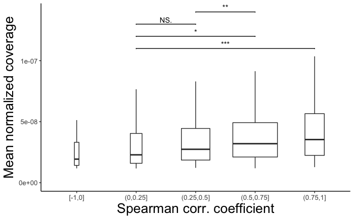

# Is average methylation different in poorly correlated regions?

I first to get the methylation fraction of each region

```bash
zcat ../kaester/met_extraction/ERR454965_1_val_1_bismark_bt2.deduplicated.bismark.cov.gz | bedtools intersect -a stdin -b artificial_coverage/highcov.random.42.bed -wo | bedtools groupby -g 7,8,9 -c 5,6 -o sum,sum > artificial_coverage/highcov.random.42.metfrac.bed
```

Then I load and add information to the correlation data frame.

|  | id | spear | pear | spear.rand | pear.rand | mean.cov | spear.group | meths |
| --- | --- | --- | --- | --- | --- | --- | --- | --- |
| 1 | chr1 (1.0004e+08,1.00055e+08] | 0.44259084 | 0.5361064 | -0.003024831 | 0.006855553 | 1.539267e-08 | (0.25,0.5] | 3.0952381 |
| 2 | chr1 (1.02585e+08,1.02595e+08] | 0.61172854 | 0.5601997 | 0.001325281 | -0.013694695 | 2.651714e-08 | (0.5,0.75] | 1.6576251 |
| 3 | chr1 (1.03155e+08,1.03165e+08] | -0.02090805 | 0.4308133 | 0.019894466 | 0.010151483 | 1.933498e-08 | [-1,0] | 5.1745252 |
| 4 | chr1 (1.03195e+08,1.0321e+08] | 0.52327541 | 0.4788734 | -0.017515204 | -0.007938749 | 2.173525e-08 | (0.5,0.75] | 1.2922705 |
| 5 | chr1 (1.0384e+08,1.03855e+08] | 0.74090669 | 0.7289780 | -0.006047623 | 0.002564070 | 2.073283e-08 | (0.5,0.75] | 0.9689922 |
| 6 | chr1 (1.04755e+08,1.04835e+08] | 0.70168488 | 0.5272285 | 0.007579060 | 0.005868105 | 2.090202e-08 | (0.5,0.75] | 5.9981685 |

Average methylation doesn’t seem to be different in poorly correlated regions.

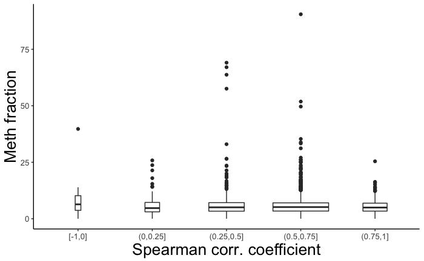

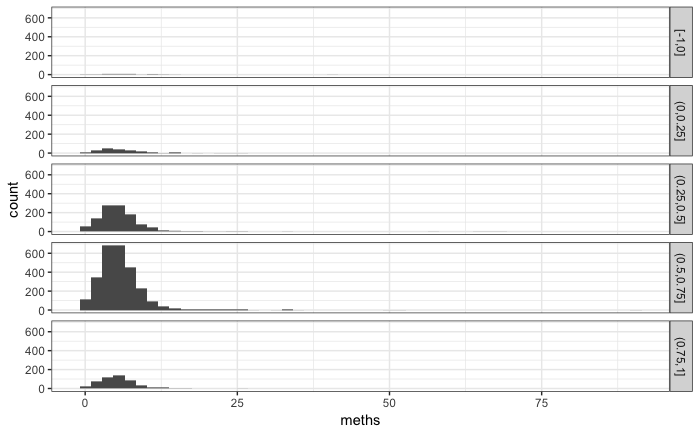

## Outliars: same ranking, different amplitudes

Checking regions with high spearman and low pearson

```r
outliar1 <- correlation %>% filter(spear>0.5 & pear<0.3)
```

```
Error in eval(lhs, parent, parent) : object 'correlation' not found
```

```r
outmax <- sapply(l.norm.smooth.common[outliar1$id], function(x) max(x$score))
outmean <- sapply(l.norm.smooth.common[outliar1$id], function(x) mean(x$score))
rand.smp <- sample(l.norm.smooth.common, length(outliar1$id))
randmax <- sapply(rand.smp, function(x) max(x$score))
randmean <- sapply(rand.smp, function(x) mean(x$score))
t.max <- t.test(outmax,randmax)
t.ratiomaxmean <- t.test(outmax/outmean, randmax/randmean)
graphics::boxplot(outmax, randmax, varwidth=TRUE, names = c('outliars', 'random'), ylab='max(coverage)', outline=FALSE)
graphics::boxplot(outmax/outmean, randmax/randmean, varwidth=TRUE, names = c('outliars', 'random'), ylab='max(coverage)/mean(coverage)', outline=FALSE)
graphics::boxplot(outmean, randmean, varwidth=TRUE, names = c('outliars', 'random'), ylab='mean(coverage)', outline=FALSE)
# legend("topright", legend = c(as.character(t$p.value)))
```

[output not shown]

Methylation:

```r
outmet <- sapply(l.norm.smooth.common[outliar1$id], get.avg.methylation, baseres.met=baseres.met)
randmet <- sapply(rand.smp, get.avg.methylation, baseres.met=baseres.met)
t.test(outmet, randmet)
boxplot(outmet, randmet, names=c('outliars', 'random'), ylab='avg. methylation')
```

[output not shown]

What about methylation?

```r
plot(density(unlist(sapply(l.norm.smooth.common[outliar1$id], function(x) get.range.methylation(x, baseres.met=baseres.met)$X))), main='Met outliars')
plot(density(baseres.met$frac), main='Met all')
```

[output not shown]

## Can I use the ranking adjustment to detect the regions with the different peaks

```r
better <- cor.df %>% filter(adj.cor > cor)
worse <- cor.df %>% filter(adj.cor < cor)
```

Regions with improved PCC

```r
sapply(sample(adj.smp[better$id],3), function(test.bw) plot.expVSpred.coverage.track(test.bw, met=get.range.methylation(test.bw, baseres.met)))
```

[output not shown]

Regions with lower PCC

```r
sapply(sample(adj.smp[worse$id],3), function(test.bw) plot.expVSpred.coverage.track(test.bw, met=get.range.methylation(test.bw, baseres.met)))
```

[output not shown]

# How does methylation goes in regions with DeltaPCC < 0?

Visualize also methylation levels in the genome track. Make base resolution met for the sampled regions

```bash
zcat ../kaester/met_extraction/ERR454965_1_val_1_bismark_bt2.deduplicated.bismark.cov.gz |
bedtools intersect -a stdin -b artificial_coverage/highcov.random.42.bed -wo |
cut -f 1,2,3,4,5,6 |
awk '$6+$5>5' > artificial_coverage/highcov.random.42.metfrac.baseres.filt5.bed
```

Load it

```r
baseres.met.bed <- '~/mnt/edann/hexamers/strand_specific/artificial_coverage/highcov.random.42.metfrac.baseres.filt5.bed'
baseres.met <- import(baseres.met.bed, format='bedGraph')
baseres.met@ranges <- resize(baseres.met@ranges, 1)
colnames(values(baseres.met)) <- c('frac','C', 'T')
```

Checking correlation between Difference in PCC and average methylation for sampled regions

```r
t.test(worse$met, better$met)
```

```
    Welch Two Sample t-test

data:  worse$met and better$met
t = -0.30068, df = 475.09, p-value = 0.7638
alternative hypothesis: true difference in means is not equal to 0
95 percent confidence interval:
 -0.6559956  0.4818788
sample estimates:
mean of x mean of y
 5.438949  5.526007
```

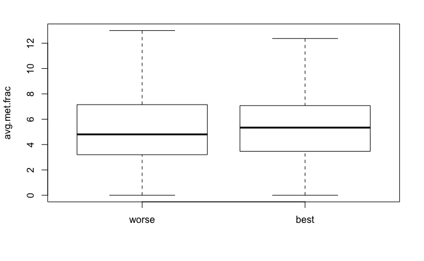

```r
boxplot(worse$met, better$met, var.width=TRUE, outline=FALSE, names=c('worse', 'best'), ylab='avg.met.frac')
```

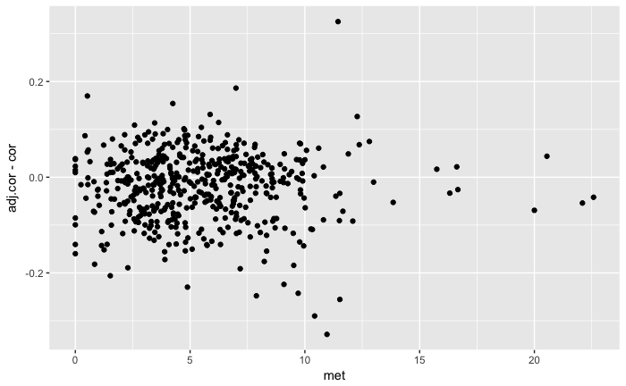

```r
ggplot(rbind(worse, better), aes(met, adj.cor - cor)) + geom_point()
```